# week_07_continue_visualizations

## More continuous variables?

### 3 variables?

```python
penguins.describe()
```

|  | bill_length_mm | bill_depth_mm | flipper_length_mm | body_mass_g |
| --- | --- | --- | --- | --- |
| count | 342.000000 | 342.000000 | 342.000000 | 342.000000 |
| mean | 43.921930 | 17.151170 | 200.915205 | 4201.754386 |
| std | 5.459584 | 1.974793 | 14.061714 | 801.954536 |
| min | 32.100000 | 13.100000 | 172.000000 | 2700.000000 |
| 25% | 39.225000 | 15.600000 | 190.000000 | 3550.000000 |
| 50% | 44.450000 | 17.300000 | 197.000000 | 4050.000000 |
| 75% | 48.500000 | 18.700000 | 213.000000 | 4750.000000 |
| max | 59.600000 | 21.500000 | 231.000000 | 6300.000000 |

Color by a 3rd continuous variable.

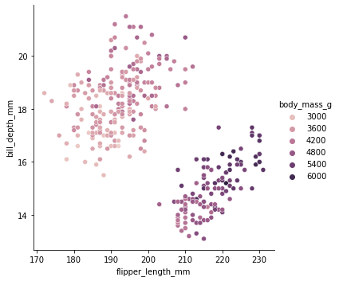

```python
sns.relplot(data = penguins, x='flipper_length_mm', y='bill_depth_mm', hue='body_mass_g')

plt.show()
```

```python
penguins.body_mass_g.nunique()
```

```
94
```

There are many different **sequential** color scales available.

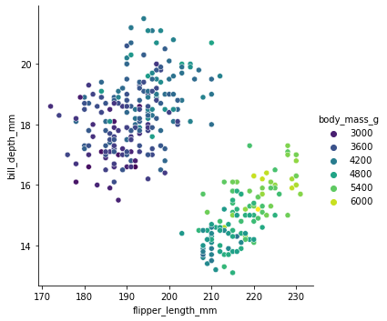

```python
sns.relplot(data = penguins, x='flipper_length_mm', y='bill_depth_mm', hue='body_mass_g',
            palette=sns.color_palette('viridis', as_cmap=True))

plt.show()
```

Reverse the color scale with the `_r` suffix.

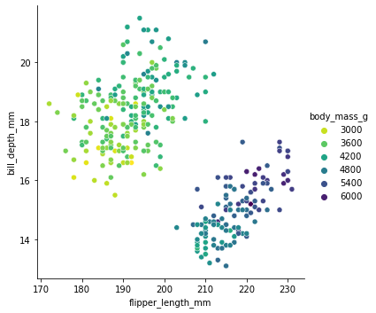

```python
sns.relplot(data = penguins, x='flipper_length_mm', y='bill_depth_mm', hue='body_mass_g',
            palette=sns.color_palette('viridis_r', as_cmap=True))

plt.show()
```

The Seaborn documentation for the color palettes.

https://seaborn.pydata.org/tutorial/color_palettes.html

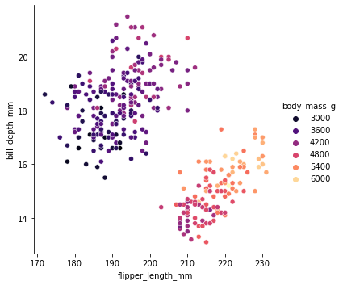

```python
sns.relplot(data = penguins, x='flipper_length_mm', y='bill_depth_mm', hue='body_mass_g',
            palette=sns.color_palette('magma', as_cmap=True))

plt.show()
```

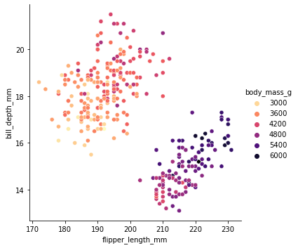

```python
sns.relplot(data = penguins, x='flipper_length_mm', y='bill_depth_mm', hue='body_mass_g',
            palette=sns.color_palette('magma_r', as_cmap=True))

plt.show()
```

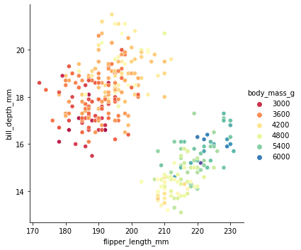

```python
sns.relplot(data = penguins, x='flipper_length_mm', y='bill_depth_mm', hue='body_mass_g',
            palette=sns.color_palette('Spectral', as_cmap=True))

plt.show()
```

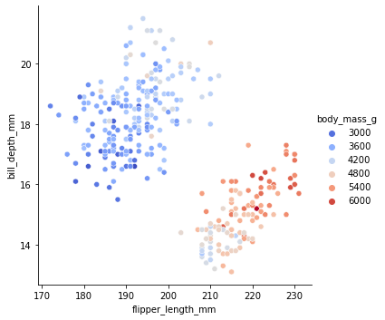

```python
sns.relplot(data = penguins, x='flipper_length_mm', y='bill_depth_mm', hue='body_mass_g',
            palette=sns.color_palette('coolwarm', as_cmap=True))

plt.show()
```

Sometimes we need to change the plot "style" to make the colors easier to see.

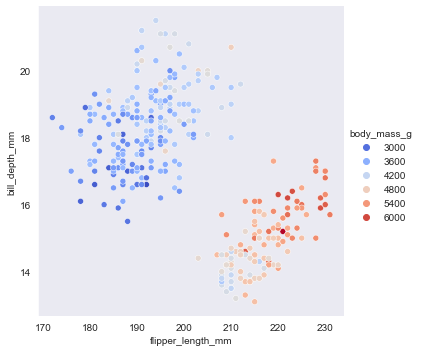

```python
sns.set_style('dark')

sns.relplot(data = penguins, x='flipper_length_mm', y='bill_depth_mm', hue='body_mass_g',
            palette=sns.color_palette('coolwarm', as_cmap=True))

plt.show()
```

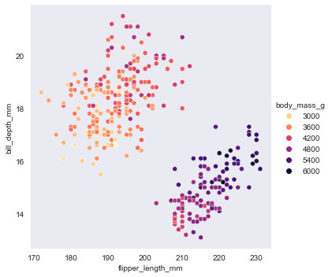

```python
sns.relplot(data = penguins, x='flipper_length_mm', y='bill_depth_mm', hue='body_mass_g',
            palette=sns.color_palette('magma_r', as_cmap=True))

plt.show()
```

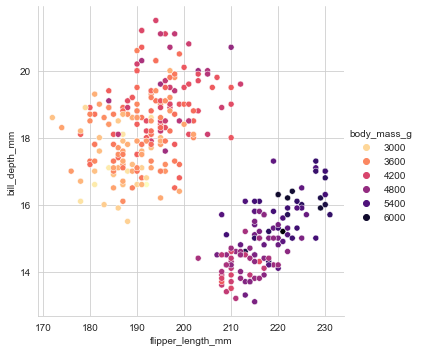

```python
sns.set_style('whitegrid')

sns.relplot(data = penguins, x='flipper_length_mm', y='bill_depth_mm', hue='body_mass_g',
            palette=sns.color_palette('magma_r', as_cmap=True))

plt.show()
```

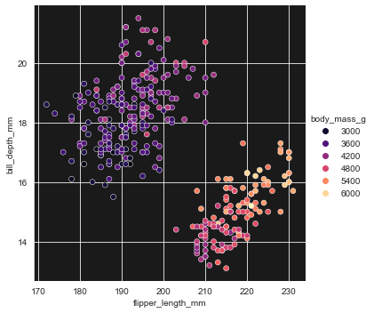

```python
sns.set_style('darkgrid', {'axes.facecolor': '.1'})

sns.relplot(data = penguins, x='flipper_length_mm', y='bill_depth_mm', hue='body_mass_g',
            palette=sns.color_palette('magma', as_cmap=True))

plt.show()
```

```python
sns.set_style('white')
```

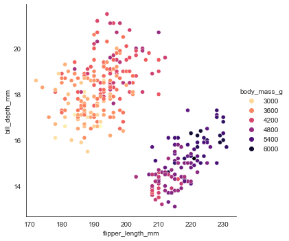

```python
sns.relplot(data = penguins, x='flipper_length_mm', y='bill_depth_mm', hue='body_mass_g',
            palette=sns.color_palette('magma_r', as_cmap=True))

plt.show()
```

Seaborn documentation on the style aesthetics.

https://seaborn.pydata.org/tutorial/aesthetics.html

## Pairsplot

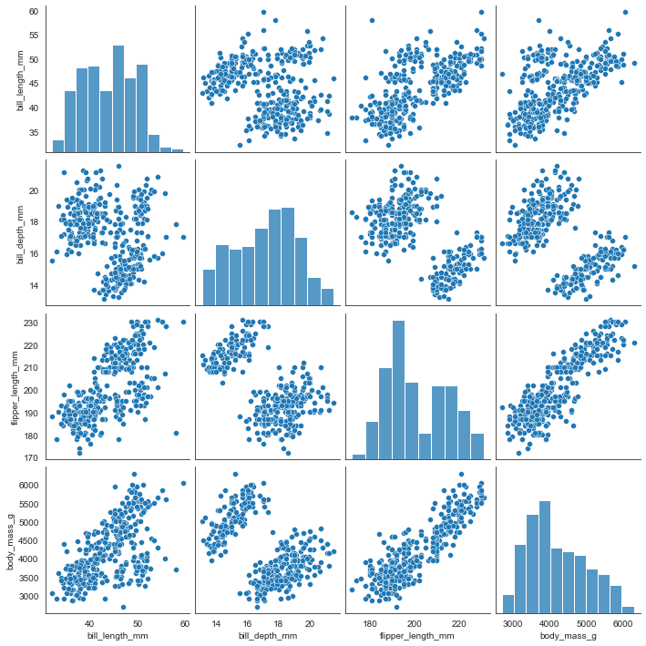

```python
sns.pairplot(data = penguins)

plt.show()
```

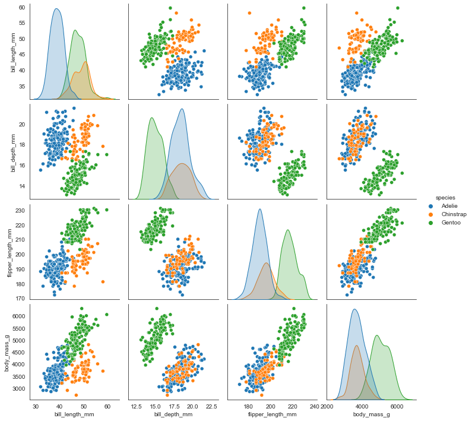

```python
sns.pairplot(data = penguins, hue='species')

plt.show()
```

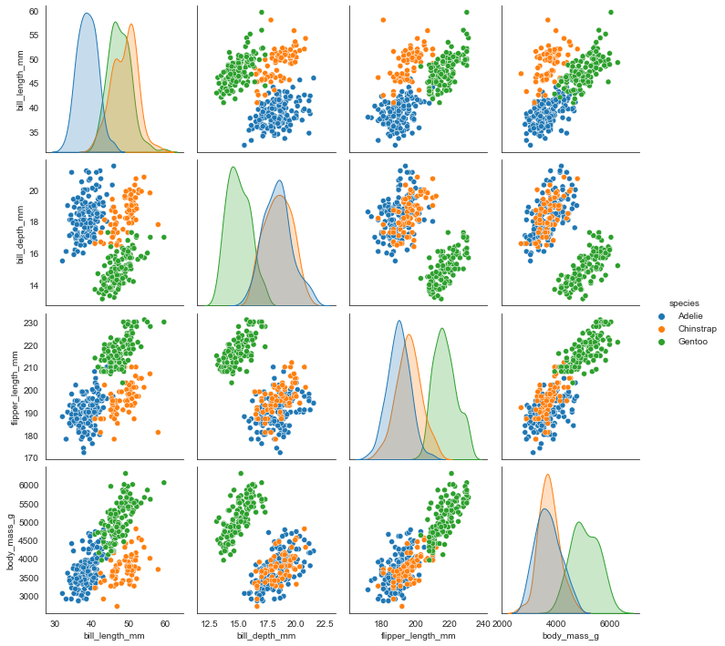

```python
sns.pairplot(data = penguins, hue='species', diag_kws={'common_norm': False})

plt.show()
```

More control over the individual components is found within the `sns.PairGrid()`.

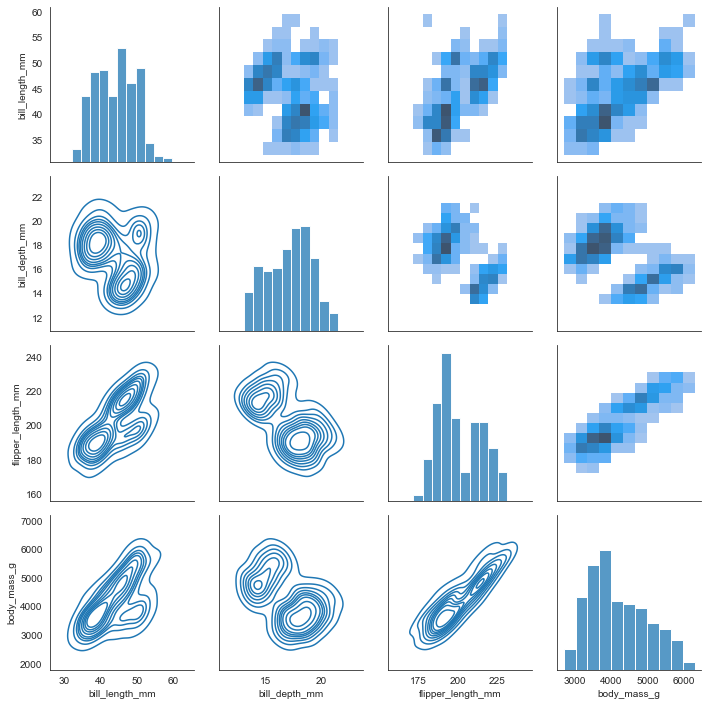

```python
g = sns.PairGrid(data = penguins)

g.map_upper(sns.histplot)
g.map_lower(sns.kdeplot)
g.map_diag(sns.histplot)

plt.show()
```

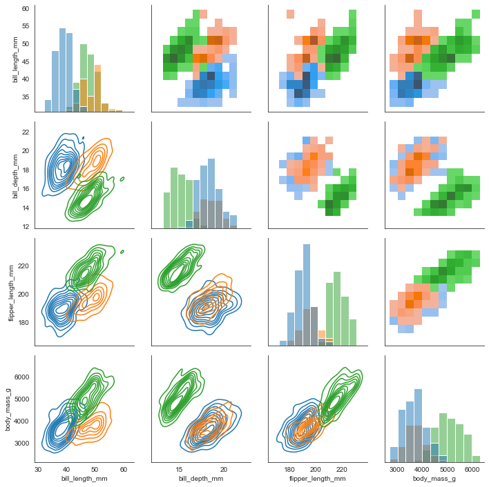

```python
g = sns.PairGrid(data = penguins, hue='species')

g.map_upper(sns.histplot)
g.map_lower(sns.kdeplot)
g.map_diag(sns.histplot)

plt.show()
```

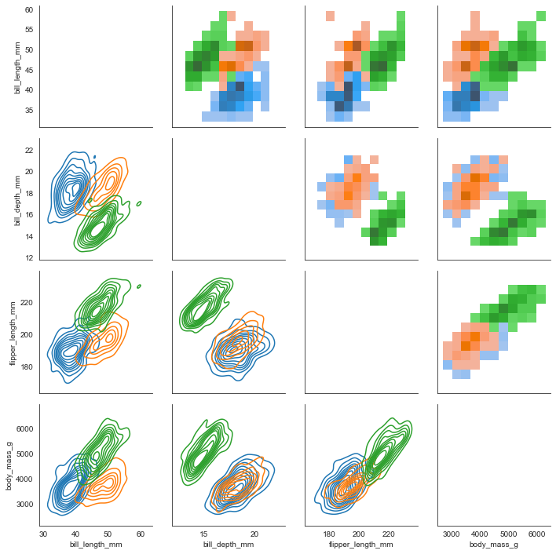

```python
g = sns.PairGrid(data = penguins, hue='species')

g.map_upper(sns.histplot)
g.map_lower(sns.kdeplot)


plt.show()
```

## Correlation plots

```python
penguins.corr()
```

|  | bill_length_mm | bill_depth_mm | flipper_length_mm | body_mass_g |
| --- | --- | --- | --- | --- |
| bill_length_mm | 1.000000 | -0.235053 | 0.656181 | 0.595110 |
| bill_depth_mm | -0.235053 | 1.000000 | -0.583851 | -0.471916 |
| flipper_length_mm | 0.656181 | -0.583851 | 1.000000 | 0.871202 |
| body_mass_g | 0.595110 | -0.471916 | 0.871202 | 1.000000 |

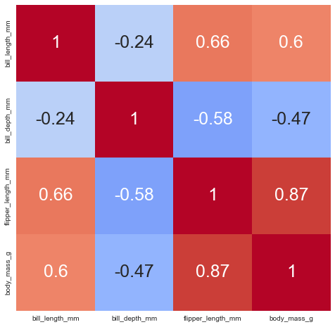

```python
fig, ax = plt.subplots(figsize=(8,8))

sns.heatmap(data = penguins.corr(),
            vmin=-1, vmax=1, center=0,
            cmap='coolwarm', cbar=False,
            annot=True, annot_kws={'size': 25},
            ax=ax)

plt.show()
```

Correlation plot per group.

```python
penguins.groupby(['species']).corr()
```

| species |  | bill_length_mm | bill_depth_mm | flipper_length_mm | body_mass_g |
| --- | --- | --- | --- | --- | --- |
| Adelie | bill_length_mm | 1.000000 | 0.391492 | 0.325785 | 0.548866 |
|  | bill_depth_mm | 0.391492 | 1.000000 | 0.307620 | 0.576138 |
|  | flipper_length_mm | 0.325785 | 0.307620 | 1.000000 | 0.468202 |
|  | body_mass_g | 0.548866 | 0.576138 | 0.468202 | 1.000000 |
| Chinstrap | bill_length_mm | 1.000000 | 0.653536 | 0.471607 | 0.513638 |
|  | bill_depth_mm | 0.653536 | 1.000000 | 0.580143 | 0.604498 |
|  | flipper_length_mm | 0.471607 | 0.580143 | 1.000000 | 0.641559 |
|  | body_mass_g | 0.513638 | 0.604498 | 0.641559 | 1.000000 |
| Gentoo | bill_length_mm | 1.000000 | 0.643384 | 0.661162 | 0.669166 |
|  | bill_depth_mm | 0.643384 | 1.000000 | 0.706563 | 0.719085 |
|  | flipper_length_mm | 0.661162 | 0.706563 | 1.000000 | 0.702667 |
|  | body_mass_g | 0.669166 | 0.719085 | 0.702667 | 1.000000 |

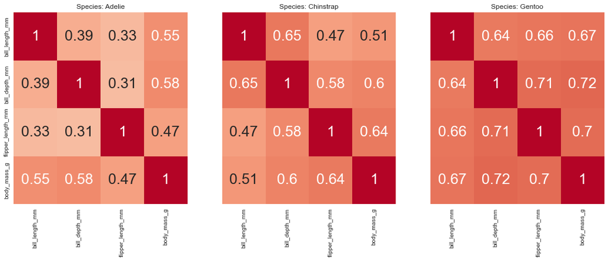

```python
fig, axs = plt.subplots(1, len(the_species), figsize=(18,6), sharex=True, sharey=True)

for ix, x in enumerate(the_species):
    sns.heatmap(data = penguins.groupby(['species']).corr().loc[x],
                vmin=-1, vmax=1, center=0,
                cmap='coolwarm', cbar=False,
                annot=True, annot_kws={'size': 25},
                ax=axs[ix])

    axs[ix].set_title('Species: '+x)

plt.show()
```